# Module 95

#### Hemi-module gene counts:

179 probesets in hemi-module A.  
145 probesets in hemi-module B.  
Note: While the mapping of probesets to genes is usually one-to-one, some genes are targeted by multiple probesets, some probesets target multiple genes, and some probesets do not target any genes (i.e., the region of the genome they match is no longer considered genic).

#### Contrast SVE:

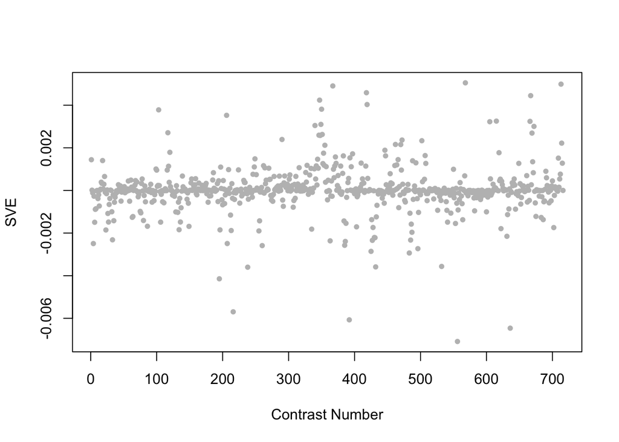

Positive SVE Contrasts:

|  | Contrast.Num | SVE | GEO.GSE | Cond.1 | Cond.2 | Mutation |
| --- | --- | --- | --- | --- | --- | --- |
| GSE2180.s4t6.vs.s3t6 | 568 | 0.01 | GSE2180 | pp83-1 | p83-2 | pal-1(RNAi) |
| GSE11055.s2t4.vs.s2t2 | 713 | 0.00 | GSE11055 | L1 larvae 3 hr after hatching in the absence of food | L1 larvae 0 hr after hatching in the absence of food |  |
| GSE35360A.s1t1.vs.s0t1 | 367 | 0.00 | GSE35360 | HF 11d_0.2_rep1 | HF 11d control_rep1 |  |
| GSE28856.s0t3.vs.s0t1 | 418 | 0.00 | GSE28856 | Wild-type 2 h after shifting temperature rep1 | Wild-type 0 h after shifting temperature rep1 |  |
| GSE15159.s2t2.vs.s2t1 | 667 | 0.00 | GSE15159 | xpa-1_UV_2007_rep1 | xpa-1_control_2007_rep1 |  |

Negative SVE Contrasts:

|  | Contrast.Num | SVE | GEO.GSE | Cond.1 | Cond.2 | Mutation |
| --- | --- | --- | --- | --- | --- | --- |
| GSE2180.s4t4.vs.s3t4 | 556 | -0.01 | GSE2180 | pp53-1 | p53-2 |  |
| GSE18132.s2t2.vs.s0t2 | 636 | -0.01 | GSE18132 | Oga Fed L4, biological replicate 1 | WT Fed L4, biological rep1 | oga-1 |
| GSE32339.s1t2.vs.s0t2 | 392 | -0.01 | GSE32339 | Adult Mutant, biological rep1 | Adult Wild-type, biological rep1 | nep-1 |
| GSE42592A.s1t2.vs.s0t2 | 216 | -0.01 | GSE42592 | acrylamide_low_expose-4h_rep1 | acrylamide_control_expose-4h_rep1 |  |
| GSE43959.s2t1.vs.s3t1 | 195 | -0.00 | GSE43959 | N2 young adult on E. coli HT115 rep 1 | N2 young adult on Comamonas DA1877 rep 1 |  |

$~$

#### Contrast SVE, Up-Regulated Genes Only:

Calculating SVE for up-regulated and down-regulated genes separately may be more informative in many cases than projecting the up- and down- gene sets together. This is due to the fact that the weight distribution of many modules is highly skewed, indicating that only one of the hemi-modules may be biologically meaningful (i.e., a set of genes are strongly correlated by only a few genes (or none) are strongly anti-correlated to that set.)

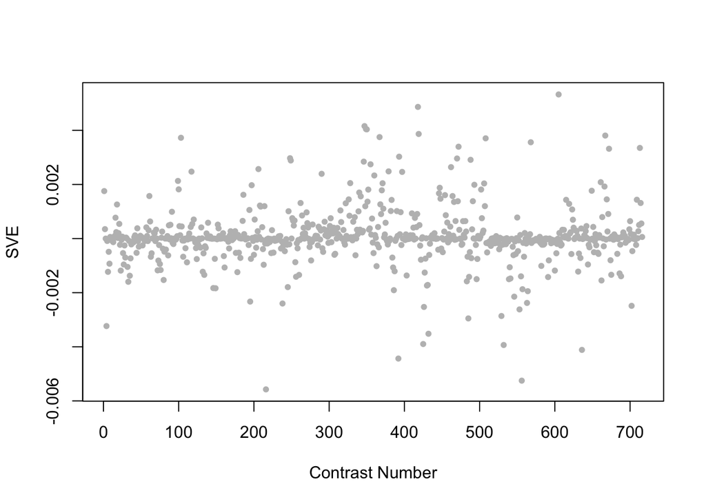

Positive SVE Contrasts:

|  | Contrast.Num | SVE | GEO.GSE | Cond.1 | Cond.2 | Mutation |
| --- | --- | --- | --- | --- | --- | --- |
| GSE21784.s2t1.vs.s3t1 | 605 | 0.01 | GSE21784 | day 6 adults, biological rep 1 | day 15 adults, biological rep 1 |  |
| GSE28856.s0t3.vs.s0t1 | 418 | 0.00 | GSE28856 | Wild-type 2 h after shifting temperature rep1 | Wild-type 0 h after shifting temperature rep1 |  |
| GSE38997.s2t3.vs.s2t1 | 347 | 0.00 | GSE38997 | experiment 1 EtBr-exposed samples at 48 h 1e48 | experiment 4 EtBr-exposed samples at 3 h 4e3 |  |
| GSE38997.s2t2.vs.s2t1 | 349 | 0.00 | GSE38997 | experiment 4 EtBr-exposed samples at 24 h 4e24 | experiment 4 EtBr-exposed samples at 3 h 4e3 |  |
| GSE38997.s3t3.vs.s3t1 | 350 | 0.00 | GSE38997 | experiment 1 UVC- and EtBr-exposed samples at 48 h 1eu48 | experiment 4 UVC- and EtBr-exposed samples at 3 h 4eu3 |  |

Negative SVE Contrasts:

|  | Contrast.Num | SVE | GEO.GSE | Cond.1 | Cond.2 | Mutation |
| --- | --- | --- | --- | --- | --- | --- |
| GSE42592A.s1t2.vs.s0t2 | 216 | -0.01 | GSE42592 | acrylamide_low_expose-4h_rep1 | acrylamide_control_expose-4h_rep1 |  |
| GSE2180.s4t4.vs.s3t4 | 556 | -0.01 | GSE2180 | pp53-1 | p53-2 |  |
| GSE32339.s1t2.vs.s0t2 | 392 | -0.00 | GSE32339 | Adult Mutant, biological rep1 | Adult Wild-type, biological rep1 | nep-1 |
| GSE18132.s2t2.vs.s0t2 | 636 | -0.00 | GSE18132 | Oga Fed L4, biological replicate 1 | WT Fed L4, biological rep1 | oga-1 |
| GSE2180.s4t9.vs.s3t9 | 532 | -0.00 | GSE2180 | pp143-1 | p143-2 | pal-1(RNAi) |

$~$

#### Contrast SVE, Down-Regulated Genes Only:

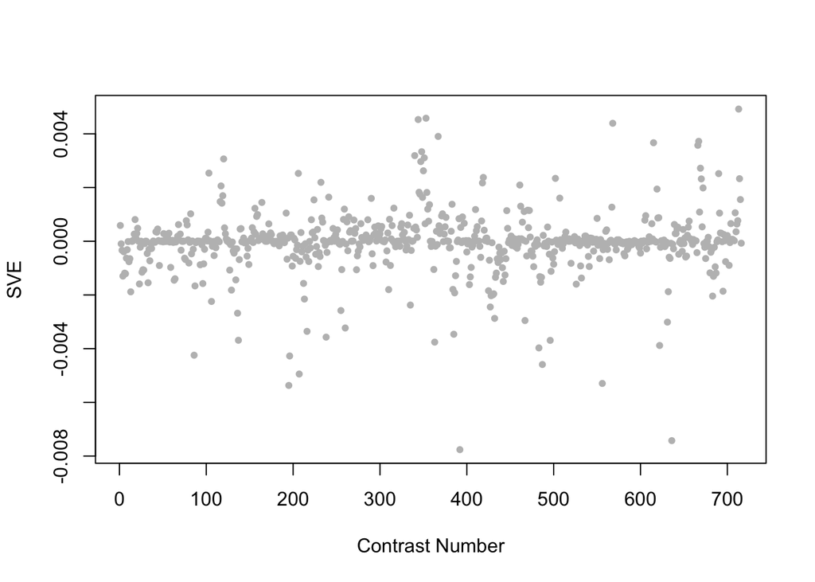

Positive SVE Contrasts:

|  | Contrast.Num | SVE | GEO.GSE | Cond.1 | Cond.2 | Mutation |
| --- | --- | --- | --- | --- | --- | --- |
| GSE11055.s2t4.vs.s2t2 | 713 | 0.00 | GSE11055 | L1 larvae 3 hr after hatching in the absence of food | L1 larvae 0 hr after hatching in the absence of food |  |
| GSE38997.s4t3.vs.s4t1 | 353 | 0.00 | GSE38997 | experiment 1 UVC-exposed samples at 48 h 1u48 | experiment 4 UVC-exposed samples at 3 h 4u3 |  |
| GSE38997.s1t3.vs.s1t1 | 344 | 0.00 | GSE38997 | experiment 1 control samples at 48 h 1c48 | experiment 4 control samples at 3 h 4c3 |  |
| GSE2180.s4t6.vs.s3t6 | 568 | 0.00 | GSE2180 | pp83-1 | p83-2 | pal-1(RNAi) |
| GSE35360A.s1t1.vs.s0t1 | 367 | 0.00 | GSE35360 | HF 11d_0.2_rep1 | HF 11d control_rep1 |  |

Negative SVE Contrasts:

|  | Contrast.Num | SVE | GEO.GSE | Cond.1 | Cond.2 | Mutation |
| --- | --- | --- | --- | --- | --- | --- |
| GSE32339.s1t2.vs.s0t2 | 392 | -0.01 | GSE32339 | Adult Mutant, biological rep1 | Adult Wild-type, biological rep1 | nep-1 |
| GSE18132.s2t2.vs.s0t2 | 636 | -0.01 | GSE18132 | Oga Fed L4, biological replicate 1 | WT Fed L4, biological rep1 | oga-1 |
| GSE43959.s2t1.vs.s3t1 | 195 | -0.01 | GSE43959 | N2 young adult on E. coli HT115 rep 1 | N2 young adult on Comamonas DA1877 rep 1 |  |
| GSE2180.s4t4.vs.s3t4 | 556 | -0.01 | GSE2180 | pp53-1 | p53-2 |  |
| GSE42703.s1t2.vs.s1t1 | 207 | -0.00 | GSE42703 | kgb-1 incubated with H2O, biological rep1 | kgb-1 incubated with 1mM copper sulfate, biological rep1 |  |

$~$

$~$

#### GO Term Enrichment:

This analysis tests each hemi-module for enrichment of specific GO terms. Only gene-level annotations (e.g., as would be found on the gene’s page in Wormbase) are tested - the hierarchical structure of the GO ontology is not taken into account.

*Note: At least the top two most enriched terms from each GO domain (BP/MF/CC) are shown, even when not statistically significant.*

##### Enriched GO terms: Hemi-module A

| ID | GO.Term | GO Domain | Raw p-value | Adj p-value |
| --- | --- | --- | --- | --- |
| [GO_0009410](http://amigo.geneontology.org/amigo/term/GO:0009410) | response to xenobiotic stimulus | BP | 1.80e-03 | 9.96e-01 |
| [GO_0035235](http://amigo.geneontology.org/amigo/term/GO:0035235) | ionotropic glutamate receptor signaling pathway | BP | 2.24e-03 | 9.96e-01 |
| [GO_0004970](http://amigo.geneontology.org/amigo/term/GO:0004970) | ionotropic glutamate receptor activity | MF | 1.80e-03 | 9.99e-01 |
| [GO_1904315](http://amigo.geneontology.org/amigo/term/GO:1904315) | transmitter-gated ion channel activity involved in regulation of postsynaptic membrane potential | MF | 1.80e-03 | 9.99e-01 |
| [GO_0098839](http://amigo.geneontology.org/amigo/term/GO:0098839) | postsynaptic density membrane | CC | 2.24e-03 | 9.97e-01 |
| [GO_0035060](http://amigo.geneontology.org/amigo/term/GO:0035060) | brahma complex | CC | 1.44e-02 | 9.97e-01 |

##### Enriched GO terms: Hemi-module B

| ID | GO.Term | GO Domain | Raw p-value | Adj p-value |
| --- | --- | --- | --- | --- |
| [GO_0010035](http://amigo.geneontology.org/amigo/term/GO:0010035) | response to inorganic substance | BP | 2.37e-03 | 9.97e-01 |
| [GO_1902074](http://amigo.geneontology.org/amigo/term/GO:1902074) | response to salt | BP | 2.79e-03 | 9.97e-01 |
| [GO_0004803](http://amigo.geneontology.org/amigo/term/GO:0004803) | transposase activity | MF | 6.15e-03 | 1.00e+00 |
| [GO_0015362](http://amigo.geneontology.org/amigo/term/GO:0015362) | high-affinity sodium:dicarboxylate symporter activity | MF | 6.15e-03 | 1.00e+00 |
| [GO_0005883](http://amigo.geneontology.org/amigo/term/GO:0005883) | neurofilament | CC | 6.15e-03 | 9.98e-01 |
| [GO_0005964](http://amigo.geneontology.org/amigo/term/GO:0005964) | phosphorylase kinase complex | CC | 1.83e-02 | 9.98e-01 |

$~$

$~$

#### Tissue Enrichment:

This analysis tests each hemi-module for enrichment of genes associated with anatomy terms. Negative enrichment scores indicate fewer hemi-module genes than expected by random chance were associated with the anatomy term in question.

##### Enriched tissues: Hemi-module A

No significant annotations.

##### Enriched tissues: Hemi-module B

No significant annotations.

$~$

$~$

#### HOMER promoter motif enrichment:

This analysis tests each hemi-module for enrichment of 108 known *C. elegans* transcription factor binding site motifs (see [108 CE motifs](https://katiepod.github.io//all.worm.motifs.html)) using the HOMER (Hypergeometric Optimization of Motif EnRichment) software (see [PMID:20513432](https://pubmed.ncbi.nlm.nih.gov/20513432)). HOMER was run using default parameters on sequences 1 kb upstream of the transcription start site.

##### Motif enrichment: Hemi-module A

Total target sequences = 137  
Total background sequences = 40103  
* - possible false positive

Rank

Motif

P-value

log P-pvalue

% of Targets

% of Background

STD(Bg STD)

Best Match/Details

Motif File

1 *

[figure not shown]

1e-9

-2.292e+01

9.49%

0.78%

316.9bp (303.9bp)

blmp-1/MA0537.1/Jaspar(0.555)  
[More Information](https://katiepod.github.io/HomerResults/m95_a_hemi_genes.txt.out.1kb/homerResults/motif1.info.html) | [Similar Motifs Found](https://katiepod.github.io/HomerResults/m95_a_hemi_genes.txt.out.1kb/homerResults/motif1.similar.html)

[motif file (matrix)](https://katiepod.github.io/HomerResults/m95_a_hemi_genes.txt.out.1kb/homerResults/motif1.motif)

2 *

[figure not shown]

1e-9

-2.145e+01

34.31%

13.43%

314.6bp (309.8bp)

POL013.1_MED-1/Jaspar(0.590)  
[More Information](https://katiepod.github.io/HomerResults/m95_a_hemi_genes.txt.out.1kb/homerResults/motif2.info.html) | [Similar Motifs Found](https://katiepod.github.io/HomerResults/m95_a_hemi_genes.txt.out.1kb/homerResults/motif2.similar.html)

[motif file (matrix)](https://katiepod.github.io/HomerResults/m95_a_hemi_genes.txt.out.1kb/homerResults/motif2.motif)

3 *

[figure not shown]

1e-8

-2.043e+01

8.03%

0.61%

241.1bp (307.5bp)

SD0001.1_at_AC_acceptor/Jaspar(0.589)  
[More Information](https://katiepod.github.io/HomerResults/m95_a_hemi_genes.txt.out.1kb/homerResults/motif3.info.html) | [Similar Motifs Found](https://katiepod.github.io/HomerResults/m95_a_hemi_genes.txt.out.1kb/homerResults/motif3.similar.html)

[motif file (matrix)](https://katiepod.github.io/HomerResults/m95_a_hemi_genes.txt.out.1kb/homerResults/motif3.motif)

4 *

[figure not shown]

1e-8

-2.041e+01

8.76%

0.78%

271.9bp (301.8bp)

unc-30/MA1443.1/Jaspar(0.626)  
[More Information](https://katiepod.github.io/HomerResults/m95_a_hemi_genes.txt.out.1kb/homerResults/motif4.info.html) | [Similar Motifs Found](https://katiepod.github.io/HomerResults/m95_a_hemi_genes.txt.out.1kb/homerResults/motif4.similar.html)

[motif file (matrix)](https://katiepod.github.io/HomerResults/m95_a_hemi_genes.txt.out.1kb/homerResults/motif4.motif)

5 *

[figure not shown]

1e-8

-1.991e+01

8.03%

0.64%

299.5bp (290.3bp)

PL0002.1_hlh-2::hlh-3/Jaspar(0.536)  
[More Information](https://katiepod.github.io/HomerResults/m95_a_hemi_genes.txt.out.1kb/homerResults/motif5.info.html) | [Similar Motifs Found](https://katiepod.github.io/HomerResults/m95_a_hemi_genes.txt.out.1kb/homerResults/motif5.similar.html)

[motif file (matrix)](https://katiepod.github.io/HomerResults/m95_a_hemi_genes.txt.out.1kb/homerResults/motif5.motif)

6 *

[figure not shown]

1e-8

-1.947e+01

3.65%

0.03%

342.2bp (219.0bp)

MF0011.1_HMG_class/Jaspar(0.670)  
[More Information](https://katiepod.github.io/HomerResults/m95_a_hemi_genes.txt.out.1kb/homerResults/motif6.info.html) | [Similar Motifs Found](https://katiepod.github.io/HomerResults/m95_a_hemi_genes.txt.out.1kb/homerResults/motif6.similar.html)

[motif file (matrix)](https://katiepod.github.io/HomerResults/m95_a_hemi_genes.txt.out.1kb/homerResults/motif6.motif)

7 *

[figure not shown]

1e-8

-1.857e+01

10.22%

1.36%

256.5bp (307.3bp)

ces-2/MA0922.1/Jaspar(0.618)  
[More Information](https://katiepod.github.io/HomerResults/m95_a_hemi_genes.txt.out.1kb/homerResults/motif7.info.html) | [Similar Motifs Found](https://katiepod.github.io/HomerResults/m95_a_hemi_genes.txt.out.1kb/homerResults/motif7.similar.html)

[motif file (matrix)](https://katiepod.github.io/HomerResults/m95_a_hemi_genes.txt.out.1kb/homerResults/motif7.motif)

8 *

[figure not shown]

1e-8

-1.856e+01

6.57%

0.41%

310.0bp (268.3bp)

LIN-39(Homeobox)/cElegans.L3-LIN39-ChIP-Seq(modEncode)/Homer(0.659)  
[More Information](https://katiepod.github.io/HomerResults/m95_a_hemi_genes.txt.out.1kb/homerResults/motif8.info.html) | [Similar Motifs Found](https://katiepod.github.io/HomerResults/m95_a_hemi_genes.txt.out.1kb/homerResults/motif8.similar.html)

[motif file (matrix)](https://katiepod.github.io/HomerResults/m95_a_hemi_genes.txt.out.1kb/homerResults/motif8.motif)

9 *

[figure not shown]

1e-7

-1.802e+01

5.84%

0.30%

203.4bp (279.9bp)

mab-5/MA1442.1/Jaspar(0.703)  
[More Information](https://katiepod.github.io/HomerResults/m95_a_hemi_genes.txt.out.1kb/homerResults/motif9.info.html) | [Similar Motifs Found](https://katiepod.github.io/HomerResults/m95_a_hemi_genes.txt.out.1kb/homerResults/motif9.similar.html)

[motif file (matrix)](https://katiepod.github.io/HomerResults/m95_a_hemi_genes.txt.out.1kb/homerResults/motif9.motif)

10 *

[figure not shown]

1e-7

-1.788e+01

13.14%

2.54%

263.4bp (308.0bp)

MF0009.1_TRP(MYB)_class/Jaspar(0.544)  
[More Information](https://katiepod.github.io/HomerResults/m95_a_hemi_genes.txt.out.1kb/homerResults/motif10.info.html) | [Similar Motifs Found](https://katiepod.github.io/HomerResults/m95_a_hemi_genes.txt.out.1kb/homerResults/motif10.similar.html)

[motif file (matrix)](https://katiepod.github.io/HomerResults/m95_a_hemi_genes.txt.out.1kb/homerResults/motif10.motif)

11 *

[figure not shown]

1e-7

-1.734e+01

14.60%

3.28%

301.0bp (307.3bp)

SD0003.1_at_AC_acceptor/Jaspar(0.540)  
[More Information](https://katiepod.github.io/HomerResults/m95_a_hemi_genes.txt.out.1kb/homerResults/motif11.info.html) | [Similar Motifs Found](https://katiepod.github.io/HomerResults/m95_a_hemi_genes.txt.out.1kb/homerResults/motif11.similar.html)

[motif file (matrix)](https://katiepod.github.io/HomerResults/m95_a_hemi_genes.txt.out.1kb/homerResults/motif11.motif)

12 *

[figure not shown]

1e-7

-1.719e+01

30.66%

12.74%

265.0bp (305.2bp)

POL012.1_TATA-Box/Jaspar(0.701)  
[More Information](https://katiepod.github.io/HomerResults/m95_a_hemi_genes.txt.out.1kb/homerResults/motif12.info.html) | [Similar Motifs Found](https://katiepod.github.io/HomerResults/m95_a_hemi_genes.txt.out.1kb/homerResults/motif12.similar.html)

[motif file (matrix)](https://katiepod.github.io/HomerResults/m95_a_hemi_genes.txt.out.1kb/homerResults/motif12.motif)

13 *

[figure not shown]

1e-7

-1.707e+01

2.19%

0.00%

211.3bp (0.0bp)

POL004.1_CCAAT-box/Jaspar(0.792)  
[More Information](https://katiepod.github.io/HomerResults/m95_a_hemi_genes.txt.out.1kb/homerResults/motif13.info.html) | [Similar Motifs Found](https://katiepod.github.io/HomerResults/m95_a_hemi_genes.txt.out.1kb/homerResults/motif13.similar.html)

[motif file (matrix)](https://katiepod.github.io/HomerResults/m95_a_hemi_genes.txt.out.1kb/homerResults/motif13.motif)

14 *

[figure not shown]

1e-7

-1.631e+01

8.03%

0.92%

191.6bp (300.3bp)

fkh-9/MA1440.1/Jaspar(0.596)  
[More Information](https://katiepod.github.io/HomerResults/m95_a_hemi_genes.txt.out.1kb/homerResults/motif14.info.html) | [Similar Motifs Found](https://katiepod.github.io/HomerResults/m95_a_hemi_genes.txt.out.1kb/homerResults/motif14.similar.html)

[motif file (matrix)](https://katiepod.github.io/HomerResults/m95_a_hemi_genes.txt.out.1kb/homerResults/motif14.motif)

15 *

[figure not shown]

1e-7

-1.628e+01

14.60%

3.51%

237.1bp (303.8bp)

POL012.1_TATA-Box/Jaspar(0.555)  
[More Information](https://katiepod.github.io/HomerResults/m95_a_hemi_genes.txt.out.1kb/homerResults/motif15.info.html) | [Similar Motifs Found](https://katiepod.github.io/HomerResults/m95_a_hemi_genes.txt.out.1kb/homerResults/motif15.similar.html)

[motif file (matrix)](https://katiepod.github.io/HomerResults/m95_a_hemi_genes.txt.out.1kb/homerResults/motif15.motif)

16 *

[figure not shown]

1e-6

-1.589e+01

8.76%

1.19%

274.6bp (298.1bp)

POL010.1_DCE_S_III/Jaspar(0.590)  
[More Information](https://katiepod.github.io/HomerResults/m95_a_hemi_genes.txt.out.1kb/homerResults/motif16.info.html) | [Similar Motifs Found](https://katiepod.github.io/HomerResults/m95_a_hemi_genes.txt.out.1kb/homerResults/motif16.similar.html)

[motif file (matrix)](https://katiepod.github.io/HomerResults/m95_a_hemi_genes.txt.out.1kb/homerResults/motif16.motif)

17 *

[figure not shown]

1e-6

-1.588e+01

10.95%

1.98%

293.5bp (303.3bp)

hlh-1/MA0545.1/Jaspar(0.676)  
[More Information](https://katiepod.github.io/HomerResults/m95_a_hemi_genes.txt.out.1kb/homerResults/motif17.info.html) | [Similar Motifs Found](https://katiepod.github.io/HomerResults/m95_a_hemi_genes.txt.out.1kb/homerResults/motif17.similar.html)

[motif file (matrix)](https://katiepod.github.io/HomerResults/m95_a_hemi_genes.txt.out.1kb/homerResults/motif17.motif)

18 *

[figure not shown]

1e-6

-1.558e+01

2.92%

0.03%

289.8bp (207.4bp)

PL0003.1_hlh-2::cnd-1/Jaspar(0.632)  
[More Information](https://katiepod.github.io/HomerResults/m95_a_hemi_genes.txt.out.1kb/homerResults/motif18.info.html) | [Similar Motifs Found](https://katiepod.github.io/HomerResults/m95_a_hemi_genes.txt.out.1kb/homerResults/motif18.similar.html)

[motif file (matrix)](https://katiepod.github.io/HomerResults/m95_a_hemi_genes.txt.out.1kb/homerResults/motif18.motif)

19 *

[figure not shown]

1e-6

-1.522e+01

5.11%

0.29%

299.6bp (315.4bp)

POL009.1_DCE_S_II/Jaspar(0.720)  
[More Information](https://katiepod.github.io/HomerResults/m95_a_hemi_genes.txt.out.1kb/homerResults/motif19.info.html) | [Similar Motifs Found](https://katiepod.github.io/HomerResults/m95_a_hemi_genes.txt.out.1kb/homerResults/motif19.similar.html)

[motif file (matrix)](https://katiepod.github.io/HomerResults/m95_a_hemi_genes.txt.out.1kb/homerResults/motif19.motif)

20 *

[figure not shown]

1e-6

-1.408e+01

2.19%

0.01%

250.0bp (234.4bp)

mab-5/MA1442.1/Jaspar(0.686)  
[More Information](https://katiepod.github.io/HomerResults/m95_a_hemi_genes.txt.out.1kb/homerResults/motif20.info.html) | [Similar Motifs Found](https://katiepod.github.io/HomerResults/m95_a_hemi_genes.txt.out.1kb/homerResults/motif20.similar.html)

[motif file (matrix)](https://katiepod.github.io/HomerResults/m95_a_hemi_genes.txt.out.1kb/homerResults/motif20.motif)

21 *

[figure not shown]

1e-6

-1.407e+01

5.11%

0.35%

289.8bp (321.9bp)

POL007.1_BREd/Jaspar(0.498)  
[More Information](https://katiepod.github.io/HomerResults/m95_a_hemi_genes.txt.out.1kb/homerResults/motif21.info.html) | [Similar Motifs Found](https://katiepod.github.io/HomerResults/m95_a_hemi_genes.txt.out.1kb/homerResults/motif21.similar.html)

[motif file (matrix)](https://katiepod.github.io/HomerResults/m95_a_hemi_genes.txt.out.1kb/homerResults/motif21.motif)

22 *

[figure not shown]

1e-5

-1.348e+01

6.57%

0.76%

256.5bp (296.4bp)

MF0008.1_MADS_class/Jaspar(0.663)  
[More Information](https://katiepod.github.io/HomerResults/m95_a_hemi_genes.txt.out.1kb/homerResults/motif22.info.html) | [Similar Motifs Found](https://katiepod.github.io/HomerResults/m95_a_hemi_genes.txt.out.1kb/homerResults/motif22.similar.html)

[motif file (matrix)](https://katiepod.github.io/HomerResults/m95_a_hemi_genes.txt.out.1kb/homerResults/motif22.motif)

23 *

[figure not shown]

1e-4

-1.137e+01

1.46%

0.00%

218.7bp (0.0bp)

GEI-11(Myb?)/cElegans-L4-GEI11-ChIP-Seq(modEncode)/Homer(0.550)  
[More Information](https://katiepod.github.io/HomerResults/m95_a_hemi_genes.txt.out.1kb/homerResults/motif23.info.html) | [Similar Motifs Found](https://katiepod.github.io/HomerResults/m95_a_hemi_genes.txt.out.1kb/homerResults/motif23.similar.html)

[motif file (matrix)](https://katiepod.github.io/HomerResults/m95_a_hemi_genes.txt.out.1kb/homerResults/motif23.motif)

24 *

[figure not shown]

1e-4

-1.040e+01

8.76%

2.05%

231.8bp (314.6bp)

efl-1/MA0541.1/Jaspar(0.620)  
[More Information](https://katiepod.github.io/HomerResults/m95_a_hemi_genes.txt.out.1kb/homerResults/motif24.info.html) | [Similar Motifs Found](https://katiepod.github.io/HomerResults/m95_a_hemi_genes.txt.out.1kb/homerResults/motif24.similar.html)

[motif file (matrix)](https://katiepod.github.io/HomerResults/m95_a_hemi_genes.txt.out.1kb/homerResults/motif24.motif)

25 *

[figure not shown]

1e-4

-1.037e+01

3.65%

0.25%

203.9bp (310.3bp)

daf-16/MA1446.1/Jaspar(0.557)  
[More Information](https://katiepod.github.io/HomerResults/m95_a_hemi_genes.txt.out.1kb/homerResults/motif25.info.html) | [Similar Motifs Found](https://katiepod.github.io/HomerResults/m95_a_hemi_genes.txt.out.1kb/homerResults/motif25.similar.html)

[motif file (matrix)](https://katiepod.github.io/HomerResults/m95_a_hemi_genes.txt.out.1kb/homerResults/motif25.motif)

26 *

[figure not shown]

1e-4

-1.023e+01

2.19%

0.04%

212.2bp (300.0bp)

unc-30/MA1443.1/Jaspar(0.565)  
[More Information](https://katiepod.github.io/HomerResults/m95_a_hemi_genes.txt.out.1kb/homerResults/motif26.info.html) | [Similar Motifs Found](https://katiepod.github.io/HomerResults/m95_a_hemi_genes.txt.out.1kb/homerResults/motif26.similar.html)

[motif file (matrix)](https://katiepod.github.io/HomerResults/m95_a_hemi_genes.txt.out.1kb/homerResults/motif26.motif)

27 *

[figure not shown]

1e-4

-9.985e+00

9.49%

2.50%

290.6bp (301.0bp)

POL010.1_DCE_S_III/Jaspar(0.534)  
[More Information](https://katiepod.github.io/HomerResults/m95_a_hemi_genes.txt.out.1kb/homerResults/motif27.info.html) | [Similar Motifs Found](https://katiepod.github.io/HomerResults/m95_a_hemi_genes.txt.out.1kb/homerResults/motif27.similar.html)

[motif file (matrix)](https://katiepod.github.io/HomerResults/m95_a_hemi_genes.txt.out.1kb/homerResults/motif27.motif)

28 *

[figure not shown]

1e-3

-9.186e+00

18.25%

8.07%

297.4bp (301.4bp)

ceh-38/MA1699.1/Jaspar(0.720)  
[More Information](https://katiepod.github.io/HomerResults/m95_a_hemi_genes.txt.out.1kb/homerResults/motif28.info.html) | [Similar Motifs Found](https://katiepod.github.io/HomerResults/m95_a_hemi_genes.txt.out.1kb/homerResults/motif28.similar.html)

[motif file (matrix)](https://katiepod.github.io/HomerResults/m95_a_hemi_genes.txt.out.1kb/homerResults/motif28.motif)

29 *

[figure not shown]

1e-3

-8.837e+00

37.23%

23.11%

293.7bp (306.3bp)

blmp-1/MA0537.1/Jaspar(0.851)  
[More Information](https://katiepod.github.io/HomerResults/m95_a_hemi_genes.txt.out.1kb/homerResults/motif29.info.html) | [Similar Motifs Found](https://katiepod.github.io/HomerResults/m95_a_hemi_genes.txt.out.1kb/homerResults/motif29.similar.html)

[motif file (matrix)](https://katiepod.github.io/HomerResults/m95_a_hemi_genes.txt.out.1kb/homerResults/motif29.motif)

30 *

[figure not shown]

1e-3

-8.196e+00

2.19%

0.09%

241.5bp (257.1bp)

DPL-1(E2F)/cElegans-Adult-ChIP-Seq(modEncode)/Homer(0.611)  
[More Information](https://katiepod.github.io/HomerResults/m95_a_hemi_genes.txt.out.1kb/homerResults/motif30.info.html) | [Similar Motifs Found](https://katiepod.github.io/HomerResults/m95_a_hemi_genes.txt.out.1kb/homerResults/motif30.similar.html)

[motif file (matrix)](https://katiepod.github.io/HomerResults/m95_a_hemi_genes.txt.out.1kb/homerResults/motif30.motif)

31 *

[figure not shown]

1e-3

-7.385e+00

1.46%

0.02%

132.8bp (319.0bp)

POL013.1_MED-1/Jaspar(0.651)  
[More Information](https://katiepod.github.io/HomerResults/m95_a_hemi_genes.txt.out.1kb/homerResults/motif31.info.html) | [Similar Motifs Found](https://katiepod.github.io/HomerResults/m95_a_hemi_genes.txt.out.1kb/homerResults/motif31.similar.html)

[motif file (matrix)](https://katiepod.github.io/HomerResults/m95_a_hemi_genes.txt.out.1kb/homerResults/motif31.motif)

32 *

[figure not shown]

1e-3

-7.384e+00

2.92%

0.27%

255.6bp (299.3bp)

SD0003.1_at_AC_acceptor/Jaspar(0.691)  
[More Information](https://katiepod.github.io/HomerResults/m95_a_hemi_genes.txt.out.1kb/homerResults/motif32.info.html) | [Similar Motifs Found](https://katiepod.github.io/HomerResults/m95_a_hemi_genes.txt.out.1kb/homerResults/motif32.similar.html)

[motif file (matrix)](https://katiepod.github.io/HomerResults/m95_a_hemi_genes.txt.out.1kb/homerResults/motif32.motif)

33 *

[figure not shown]

1e-3

-7.205e+00

1.46%

0.03%

137.2bp (238.4bp)

elt-3/MA0542.1/Jaspar(0.620)  
[More Information](https://katiepod.github.io/HomerResults/m95_a_hemi_genes.txt.out.1kb/homerResults/motif33.info.html) | [Similar Motifs Found](https://katiepod.github.io/HomerResults/m95_a_hemi_genes.txt.out.1kb/homerResults/motif33.similar.html)

[motif file (matrix)](https://katiepod.github.io/HomerResults/m95_a_hemi_genes.txt.out.1kb/homerResults/motif33.motif)

34 *

[figure not shown]

1e-2

-5.801e+00

1.46%

0.06%

350.8bp (287.3bp)

SD0003.1_at_AC_acceptor/Jaspar(0.576)  
[More Information](https://katiepod.github.io/HomerResults/m95_a_hemi_genes.txt.out.1kb/homerResults/motif34.info.html) | [Similar Motifs Found](https://katiepod.github.io/HomerResults/m95_a_hemi_genes.txt.out.1kb/homerResults/motif34.similar.html)

[motif file (matrix)](https://katiepod.github.io/HomerResults/m95_a_hemi_genes.txt.out.1kb/homerResults/motif34.motif)

35 *

[figure not shown]

1e-2

-5.683e+00

0.73%

0.00%

0.0bp (0.0bp)

DPL-1(E2F)/cElegans-Adult-ChIP-Seq(modEncode)/Homer(0.549)  
[More Information](https://katiepod.github.io/HomerResults/m95_a_hemi_genes.txt.out.1kb/homerResults/motif35.info.html) | [Similar Motifs Found](https://katiepod.github.io/HomerResults/m95_a_hemi_genes.txt.out.1kb/homerResults/motif35.similar.html)

[motif file (matrix)](https://katiepod.github.io/HomerResults/m95_a_hemi_genes.txt.out.1kb/homerResults/motif35.motif)

36 *

[figure not shown]

1e-2

-4.866e+00

3.65%

0.88%

249.2bp (335.8bp)

POL006.1_BREu/Jaspar(0.548)  
[More Information](https://katiepod.github.io/HomerResults/m95_a_hemi_genes.txt.out.1kb/homerResults/motif36.info.html) | [Similar Motifs Found](https://katiepod.github.io/HomerResults/m95_a_hemi_genes.txt.out.1kb/homerResults/motif36.similar.html)

[motif file (matrix)](https://katiepod.github.io/HomerResults/m95_a_hemi_genes.txt.out.1kb/homerResults/motif36.motif)

37 *

[figure not shown]

1e-1

-4.291e+00

9.49%

4.73%

298.6bp (300.4bp)

elt-2/MA1701.1/Jaspar(0.554)  
[More Information](https://katiepod.github.io/HomerResults/m95_a_hemi_genes.txt.out.1kb/homerResults/motif37.info.html) | [Similar Motifs Found](https://katiepod.github.io/HomerResults/m95_a_hemi_genes.txt.out.1kb/homerResults/motif37.similar.html)

[motif file (matrix)](https://katiepod.github.io/HomerResults/m95_a_hemi_genes.txt.out.1kb/homerResults/motif37.motif)

38 *

[figure not shown]

1e-1

-2.487e+00

5.84%

3.28%

271.4bp (303.6bp)

elt-6/MA1439.1/Jaspar(0.609)  
[More Information](https://katiepod.github.io/HomerResults/m95_a_hemi_genes.txt.out.1kb/homerResults/motif38.info.html) | [Similar Motifs Found](https://katiepod.github.io/HomerResults/m95_a_hemi_genes.txt.out.1kb/homerResults/motif38.similar.html)

[motif file (matrix)](https://katiepod.github.io/HomerResults/m95_a_hemi_genes.txt.out.1kb/homerResults/motif38.motif)

##### Motif enrichment: Hemi-module B

Total target sequences = 107  
Total background sequences = 41012  
* - possible false positive

Rank

Motif

P-value

log P-pvalue

% of Targets

% of Background

STD(Bg STD)

Best Match/Details

Motif File

1 *

[figure not shown]

1e-9

-2.254e+01

21.50%

4.29%

325.8bp (287.4bp)

unc-30/MA1443.1/Jaspar(0.494)  
[More Information](https://katiepod.github.io/HomerResults/m95_b_hemi_genes.txt.out.1kb/homerResults/motif1.info.html) | [Similar Motifs Found](https://katiepod.github.io/HomerResults/m95_b_hemi_genes.txt.out.1kb/homerResults/motif1.similar.html)

[motif file (matrix)](https://katiepod.github.io/HomerResults/m95_b_hemi_genes.txt.out.1kb/homerResults/motif1.motif)

2 *

[figure not shown]

1e-9

-2.193e+01

14.95%

1.91%

301.7bp (279.5bp)

POL008.1_DCE_S_I/Jaspar(0.627)  
[More Information](https://katiepod.github.io/HomerResults/m95_b_hemi_genes.txt.out.1kb/homerResults/motif2.info.html) | [Similar Motifs Found](https://katiepod.github.io/HomerResults/m95_b_hemi_genes.txt.out.1kb/homerResults/motif2.similar.html)

[motif file (matrix)](https://katiepod.github.io/HomerResults/m95_b_hemi_genes.txt.out.1kb/homerResults/motif2.motif)

3 *

[figure not shown]

1e-8

-1.982e+01

12.15%

1.32%

308.3bp (294.7bp)

PL0017.1_hlh-2::hlh-10/Jaspar(0.567)  
[More Information](https://katiepod.github.io/HomerResults/m95_b_hemi_genes.txt.out.1kb/homerResults/motif3.info.html) | [Similar Motifs Found](https://katiepod.github.io/HomerResults/m95_b_hemi_genes.txt.out.1kb/homerResults/motif3.similar.html)

[motif file (matrix)](https://katiepod.github.io/HomerResults/m95_b_hemi_genes.txt.out.1kb/homerResults/motif3.motif)

4 *

[figure not shown]

1e-8

-1.939e+01

11.21%

1.11%

207.3bp (283.2bp)

fkh-9/MA1440.1/Jaspar(0.560)  
[More Information](https://katiepod.github.io/HomerResults/m95_b_hemi_genes.txt.out.1kb/homerResults/motif4.info.html) | [Similar Motifs Found](https://katiepod.github.io/HomerResults/m95_b_hemi_genes.txt.out.1kb/homerResults/motif4.similar.html)

[motif file (matrix)](https://katiepod.github.io/HomerResults/m95_b_hemi_genes.txt.out.1kb/homerResults/motif4.motif)

5 *

[figure not shown]

1e-8

-1.874e+01

19.63%

4.35%

284.0bp (286.7bp)

ELT-3(Gata)/cElegans-L1-ELT3-ChIP-Seq(modEncode)/Homer(0.575)  
[More Information](https://katiepod.github.io/HomerResults/m95_b_hemi_genes.txt.out.1kb/homerResults/motif5.info.html) | [Similar Motifs Found](https://katiepod.github.io/HomerResults/m95_b_hemi_genes.txt.out.1kb/homerResults/motif5.similar.html)

[motif file (matrix)](https://katiepod.github.io/HomerResults/m95_b_hemi_genes.txt.out.1kb/homerResults/motif5.motif)

6 *

[figure not shown]

1e-8

-1.867e+01

14.02%

2.07%

248.6bp (286.0bp)

MF0002.1_bZIP_CREB/G-box-like_subclass/Jaspar(0.494)  
[More Information](https://katiepod.github.io/HomerResults/m95_b_hemi_genes.txt.out.1kb/homerResults/motif6.info.html) | [Similar Motifs Found](https://katiepod.github.io/HomerResults/m95_b_hemi_genes.txt.out.1kb/homerResults/motif6.similar.html)

[motif file (matrix)](https://katiepod.github.io/HomerResults/m95_b_hemi_genes.txt.out.1kb/homerResults/motif6.motif)

7 *

[figure not shown]

1e-8

-1.863e+01

14.02%

2.08%

268.0bp (291.3bp)

che-1/MA0260.1/Jaspar(0.684)  
[More Information](https://katiepod.github.io/HomerResults/m95_b_hemi_genes.txt.out.1kb/homerResults/motif7.info.html) | [Similar Motifs Found](https://katiepod.github.io/HomerResults/m95_b_hemi_genes.txt.out.1kb/homerResults/motif7.similar.html)

[motif file (matrix)](https://katiepod.github.io/HomerResults/m95_b_hemi_genes.txt.out.1kb/homerResults/motif7.motif)

8 *

[figure not shown]

1e-7

-1.746e+01

16.82%

3.41%

288.6bp (299.4bp)

MF0005.1_Forkhead_class/Jaspar(0.675)  
[More Information](https://katiepod.github.io/HomerResults/m95_b_hemi_genes.txt.out.1kb/homerResults/motif8.info.html) | [Similar Motifs Found](https://katiepod.github.io/HomerResults/m95_b_hemi_genes.txt.out.1kb/homerResults/motif8.similar.html)

[motif file (matrix)](https://katiepod.github.io/HomerResults/m95_b_hemi_genes.txt.out.1kb/homerResults/motif8.motif)

9 *

[figure not shown]

1e-7

-1.739e+01

15.89%

3.03%

269.5bp (289.1bp)

mab-3/MA0262.1/Jaspar(0.667)  
[More Information](https://katiepod.github.io/HomerResults/m95_b_hemi_genes.txt.out.1kb/homerResults/motif9.info.html) | [Similar Motifs Found](https://katiepod.github.io/HomerResults/m95_b_hemi_genes.txt.out.1kb/homerResults/motif9.similar.html)

[motif file (matrix)](https://katiepod.github.io/HomerResults/m95_b_hemi_genes.txt.out.1kb/homerResults/motif9.motif)

10 *

[figure not shown]

1e-6

-1.571e+01

10.28%

1.27%

223.1bp (285.4bp)

blmp-1/MA0537.1/Jaspar(0.542)  
[More Information](https://katiepod.github.io/HomerResults/m95_b_hemi_genes.txt.out.1kb/homerResults/motif10.info.html) | [Similar Motifs Found](https://katiepod.github.io/HomerResults/m95_b_hemi_genes.txt.out.1kb/homerResults/motif10.similar.html)

[motif file (matrix)](https://katiepod.github.io/HomerResults/m95_b_hemi_genes.txt.out.1kb/homerResults/motif10.motif)

11 *

[figure not shown]

1e-6

-1.483e+01

7.48%

0.60%

233.4bp (287.0bp)

lin-14/MA0261.1/Jaspar(0.588)  
[More Information](https://katiepod.github.io/HomerResults/m95_b_hemi_genes.txt.out.1kb/homerResults/motif11.info.html) | [Similar Motifs Found](https://katiepod.github.io/HomerResults/m95_b_hemi_genes.txt.out.1kb/homerResults/motif11.similar.html)

[motif file (matrix)](https://katiepod.github.io/HomerResults/m95_b_hemi_genes.txt.out.1kb/homerResults/motif11.motif)

12 *

[figure not shown]

1e-6

-1.465e+01

10.28%

1.41%

243.2bp (292.9bp)

POL009.1_DCE_S_II/Jaspar(0.605)  
[More Information](https://katiepod.github.io/HomerResults/m95_b_hemi_genes.txt.out.1kb/homerResults/motif12.info.html) | [Similar Motifs Found](https://katiepod.github.io/HomerResults/m95_b_hemi_genes.txt.out.1kb/homerResults/motif12.similar.html)

[motif file (matrix)](https://katiepod.github.io/HomerResults/m95_b_hemi_genes.txt.out.1kb/homerResults/motif12.motif)

13 *

[figure not shown]

1e-6

-1.455e+01

11.21%

1.75%

258.1bp (298.0bp)

PL0001.1_hlh-11/Jaspar(0.653)  
[More Information](https://katiepod.github.io/HomerResults/m95_b_hemi_genes.txt.out.1kb/homerResults/motif13.info.html) | [Similar Motifs Found](https://katiepod.github.io/HomerResults/m95_b_hemi_genes.txt.out.1kb/homerResults/motif13.similar.html)

[motif file (matrix)](https://katiepod.github.io/HomerResults/m95_b_hemi_genes.txt.out.1kb/homerResults/motif13.motif)

14 *

[figure not shown]

1e-6

-1.454e+01

4.67%

0.13%

346.6bp (270.6bp)

hlh-1/MA0545.1/Jaspar(0.565)  
[More Information](https://katiepod.github.io/HomerResults/m95_b_hemi_genes.txt.out.1kb/homerResults/motif14.info.html) | [Similar Motifs Found](https://katiepod.github.io/HomerResults/m95_b_hemi_genes.txt.out.1kb/homerResults/motif14.similar.html)

[motif file (matrix)](https://katiepod.github.io/HomerResults/m95_b_hemi_genes.txt.out.1kb/homerResults/motif14.motif)

15 *

[figure not shown]

1e-6

-1.420e+01

7.48%

0.65%

291.8bp (299.4bp)

che-1/MA0260.1/Jaspar(0.724)  
[More Information](https://katiepod.github.io/HomerResults/m95_b_hemi_genes.txt.out.1kb/homerResults/motif15.info.html) | [Similar Motifs Found](https://katiepod.github.io/HomerResults/m95_b_hemi_genes.txt.out.1kb/homerResults/motif15.similar.html)

[motif file (matrix)](https://katiepod.github.io/HomerResults/m95_b_hemi_genes.txt.out.1kb/homerResults/motif15.motif)

16 *

[figure not shown]

1e-6

-1.392e+01

37.38%

17.53%

288.5bp (295.4bp)

mab-5/MA1442.1/Jaspar(0.906)  
[More Information](https://katiepod.github.io/HomerResults/m95_b_hemi_genes.txt.out.1kb/homerResults/motif16.info.html) | [Similar Motifs Found](https://katiepod.github.io/HomerResults/m95_b_hemi_genes.txt.out.1kb/homerResults/motif16.similar.html)

[motif file (matrix)](https://katiepod.github.io/HomerResults/m95_b_hemi_genes.txt.out.1kb/homerResults/motif16.motif)

17 *

[figure not shown]

1e-5

-1.191e+01

1.87%

0.00%

8.5bp (0.0bp)

SD0003.1_at_AC_acceptor/Jaspar(0.551)  
[More Information](https://katiepod.github.io/HomerResults/m95_b_hemi_genes.txt.out.1kb/homerResults/motif17.info.html) | [Similar Motifs Found](https://katiepod.github.io/HomerResults/m95_b_hemi_genes.txt.out.1kb/homerResults/motif17.similar.html)

[motif file (matrix)](https://katiepod.github.io/HomerResults/m95_b_hemi_genes.txt.out.1kb/homerResults/motif17.motif)

18 *

[figure not shown]

1e-4

-1.144e+01

26.17%

11.04%

332.2bp (293.5bp)

lin-14/MA0261.1/Jaspar(0.755)  
[More Information](https://katiepod.github.io/HomerResults/m95_b_hemi_genes.txt.out.1kb/homerResults/motif18.info.html) | [Similar Motifs Found](https://katiepod.github.io/HomerResults/m95_b_hemi_genes.txt.out.1kb/homerResults/motif18.similar.html)

[motif file (matrix)](https://katiepod.github.io/HomerResults/m95_b_hemi_genes.txt.out.1kb/homerResults/motif18.motif)

19 *

[figure not shown]

1e-4

-1.113e+01

5.61%

0.47%

271.9bp (301.3bp)

ceh-38/MA1699.1/Jaspar(0.547)  
[More Information](https://katiepod.github.io/HomerResults/m95_b_hemi_genes.txt.out.1kb/homerResults/motif19.info.html) | [Similar Motifs Found](https://katiepod.github.io/HomerResults/m95_b_hemi_genes.txt.out.1kb/homerResults/motif19.similar.html)

[motif file (matrix)](https://katiepod.github.io/HomerResults/m95_b_hemi_genes.txt.out.1kb/homerResults/motif19.motif)

20 *

[figure not shown]

1e-4

-9.735e+00

12.15%

3.31%

292.5bp (290.3bp)

cebp-1/MA1444.1/Jaspar(0.723)  
[More Information](https://katiepod.github.io/HomerResults/m95_b_hemi_genes.txt.out.1kb/homerResults/motif20.info.html) | [Similar Motifs Found](https://katiepod.github.io/HomerResults/m95_b_hemi_genes.txt.out.1kb/homerResults/motif20.similar.html)

[motif file (matrix)](https://katiepod.github.io/HomerResults/m95_b_hemi_genes.txt.out.1kb/homerResults/motif20.motif)

21 *

[figure not shown]

1e-3

-8.955e+00

3.74%

0.23%

114.3bp (271.4bp)

MF0004.1_Nuclear_Receptor_class/Jaspar(0.726)  
[More Information](https://katiepod.github.io/HomerResults/m95_b_hemi_genes.txt.out.1kb/homerResults/motif21.info.html) | [Similar Motifs Found](https://katiepod.github.io/HomerResults/m95_b_hemi_genes.txt.out.1kb/homerResults/motif21.similar.html)

[motif file (matrix)](https://katiepod.github.io/HomerResults/m95_b_hemi_genes.txt.out.1kb/homerResults/motif21.motif)

22 *

[figure not shown]

1e-3

-7.682e+00

10.28%

3.05%

270.5bp (309.1bp)

MF0001.1_ETS_class/Jaspar(0.643)  
[More Information](https://katiepod.github.io/HomerResults/m95_b_hemi_genes.txt.out.1kb/homerResults/motif22.info.html) | [Similar Motifs Found](https://katiepod.github.io/HomerResults/m95_b_hemi_genes.txt.out.1kb/homerResults/motif22.similar.html)

[motif file (matrix)](https://katiepod.github.io/HomerResults/m95_b_hemi_genes.txt.out.1kb/homerResults/motif22.motif)

23 *

[figure not shown]

1e-3

-7.135e+00

5.61%

1.00%

247.5bp (270.7bp)

ceh-28/MA1445.1/Jaspar(0.653)  
[More Information](https://katiepod.github.io/HomerResults/m95_b_hemi_genes.txt.out.1kb/homerResults/motif23.info.html) | [Similar Motifs Found](https://katiepod.github.io/HomerResults/m95_b_hemi_genes.txt.out.1kb/homerResults/motif23.similar.html)

[motif file (matrix)](https://katiepod.github.io/HomerResults/m95_b_hemi_genes.txt.out.1kb/homerResults/motif23.motif)

24 *

[figure not shown]

1e-2

-5.953e+00

0.93%

0.00%

54.0bp (0.0bp)

MF0004.1_Nuclear_Receptor_class/Jaspar(0.671)  
[More Information](https://katiepod.github.io/HomerResults/m95_b_hemi_genes.txt.out.1kb/homerResults/motif24.info.html) | [Similar Motifs Found](https://katiepod.github.io/HomerResults/m95_b_hemi_genes.txt.out.1kb/homerResults/motif24.similar.html)

[motif file (matrix)](https://katiepod.github.io/HomerResults/m95_b_hemi_genes.txt.out.1kb/homerResults/motif24.motif)

25 *

[figure not shown]

1e-2

-4.964e+00

5.61%

1.56%

209.9bp (277.9bp)

PL0009.1_hlh-26/Jaspar(0.564)  
[More Information](https://katiepod.github.io/HomerResults/m95_b_hemi_genes.txt.out.1kb/homerResults/motif25.info.html) | [Similar Motifs Found](https://katiepod.github.io/HomerResults/m95_b_hemi_genes.txt.out.1kb/homerResults/motif25.similar.html)

[motif file (matrix)](https://katiepod.github.io/HomerResults/m95_b_hemi_genes.txt.out.1kb/homerResults/motif25.motif)

26 *

[figure not shown]

1e-2

-4.841e+00

34.58%

23.81%

284.4bp (296.0bp)

MF0004.1_Nuclear_Receptor_class/Jaspar(0.660)  
[More Information](https://katiepod.github.io/HomerResults/m95_b_hemi_genes.txt.out.1kb/homerResults/motif26.info.html) | [Similar Motifs Found](https://katiepod.github.io/HomerResults/m95_b_hemi_genes.txt.out.1kb/homerResults/motif26.similar.html)

[motif file (matrix)](https://katiepod.github.io/HomerResults/m95_b_hemi_genes.txt.out.1kb/homerResults/motif26.motif)

$~$

$~$

#### Promoter Word Enrichment:

This analysis tests each hemi-module for enrichment of specific promoter words. The list of promoter words tested was generated by running the MobyDick algorithm (see [PMID:10944202](https://pubmed.ncbi.nlm.nih.gov/10944202)) on the full set of *C. elegans* 2 Kbp promoters.

##### Enriched promoter words: Hemi-module A

No significant words.

##### Enriched promoter words: Hemi-module B

No significant words.

$~$

$~$

#### Promoter Word Depletion:

This analysis tests each hemi-module for depletion (under-enrichment) of specific promoter words. The list of promoter words tested was generated by running the MobyDick algorithm (see [PMID:10944202](https://pubmed.ncbi.nlm.nih.gov/10944202)) on the full set of *C. elegans* 2 Kbp promoters.

##### Depleted promoter words: Hemi-module A

No significant words.

##### Depleted promoter words: Hemi-module B

No significant words.

$~$

$~$

#### 3’-UTR Word Enrichment:

This analysis tests each hemi-module for enrichment of specific 3’-UTR words. The list of words tested was generated by running the MobyDick algorithm (see [PMID:10944202](https://pubmed.ncbi.nlm.nih.gov/10944202)) on the full set of *C. elegans* 3’-UTR sequences.

##### 3’-UTR words: Hemi-module A

No significant words.

##### 3’-UTR words: Hemi-module B

No significant words.

$~$

$~$

#### Hemi-module A genes

| affy_c_elegans | ensembl_gene_id | external_gene_name | module_weight | chromosome_name | strand | start_position | end_position |
| --- | --- | --- | --- | --- | --- | --- | --- |
| 183376_at | WBGene00012686 | Y39B6A.27 | 6.26 | V | 1 | 19031742 | 19035255 |
| 186076_at | WBGene00014947 | Y71A12B.14 | 5.95 | I | 1 | 13969844 | 13970877 |
| 189058_at | WBGene00017806 | F26A1.8 | 5.69 | III | -1 | 4820670 | 4822226 |
| 184584_at | WBGene00015728 | C13A10.1 | 5.50 | II | -1 | 1350720 | 1355641 |
| 185594_at | WBGene00016484 | C36C5.15 | 5.26 | V | -1 | 3167968 | 3168750 |
| 188902_at | WBGene00012036 | clec-103 | 5.02 | I | 1 | 12683238 | 12684359 |
| 189870_at | WBGene00021731 | Y49G5A.1 | 4.93 | V | -1 | 5286407 | 5287360 |
| 180995_at | WBGene00015631 | clec-89 | 4.91 | I | -1 | 4071799 | 4073088 |
| 185931_at | WBGene00021450 | mltn-6 | 4.85 | V | 1 | 364950 | 369088 |
| 186740_s_at | WBGene00021999 | thn-5 | 4.82 | IV | 1 | 5230830 | 5232479 |
| 186740_s_at | WBGene00022001 | thn-7 | 4.82 | IV | -1 | 5237918 | 5240353 |
| 179743_at | WBGene00015199 | B0454.8 | 4.69 | II | -1 | 3040943 | 3043406 |
| 176997_at | WBGene00022374 | nhr-277 | 4.58 | IV | 1 | 2743007 | 2747476 |
| 172843_x_at | WBGene00022204 | Y73B3A.2 | 4.52 | X | -1 | 61165 | 63375 |
| 172843_x_at | WBGene00023246 | C33E10.4 | 4.52 | X | 1 | 17280761 | 17283574 |
| 185891_at | WBGene00022421 | Y102E9.3 | 4.52 | III | -1 | 6733992 | 6734520 |
| 189059_s_at | WBGene00017804 | F26A1.6 | 4.50 | III | -1 | 4816040 | 4817078 |
| 189059_s_at | WBGene00017806 | F26A1.8 | 4.50 | III | -1 | 4820670 | 4822226 |
| 176745_at | WBGene00015968 | C18C4.7 | 4.48 | V | -1 | 5550315 | 5567221 |
| 175403_s_at | WBGene00010501 | K02C4.2 | 4.48 | II | 1 | 8075760 | 8076836 |
| 185032_at | WBGene00015925 | C17H11.5 | 4.40 | X | -1 | 8183008 | 8185133 |
| 192640_at | WBGene00003664 | nhr-74 | 4.39 | I | 1 | 11429029 | 11432145 |
| 180844_at | WBGene00012810 | nceh-1 | 4.38 | V | 1 | 19377444 | 19381031 |
| 187158_at | WBGene00018050 | clec-139 | 4.37 | II | -1 | 4619988 | 4621741 |
| 180806_at | WBGene00018945 | F56C3.8 | 4.28 | X | -1 | 1384318 | 1384638 |
| 175941_at | WBGene00021747 | Y50D4C.2 | 4.28 | V | 1 | 936464 | 939228 |
| 180966_s_at | WBGene00021018 | W04B5.1 | 4.25 | III | 1 | 2428204 | 2429430 |
| 180966_s_at | WBGene00044559 | ZK380.5 | 4.25 | X | -1 | 1647991 | 1649237 |
| 188948_at | WBGene00017814 | F26A10.2 | 4.23 | X | -1 | 7630905 | 7637172 |
| 193228_at | WBGene00008047 | lact-7 | 4.19 | X | 1 | 11759198 | 11764535 |

[output cut: 154 more lines]

#### Hemi-module B genes

| affy_c_elegans | ensembl_gene_id | external_gene_name | module_weight | chromosome_name | strand | start_position | end_position |
| --- | --- | --- | --- | --- | --- | --- | --- |
| 180773_at | WBGene00015573 | C07G1.7 | -11.50 | IV | -1 | 8210954 | 8211828 |
| 179918_at | WBGene00018024 | F35A5.1 | -5.71 | X | 1 | 3807460 | 3816429 |
| 172341_x_at | WBGene00235364 | F49F1.4 | -4.68 | IV | -1 | 4115576 | 4115734 |
| 172051_x_at | WBGene00013826 | Y116F11B.10 | -4.62 | V | 1 | 19870506 | 19873931 |
| 172051_x_at | WBGene00022213 | Y73B3A.11 | -4.62 | X | 1 | 146463 | 148812 |
| 185286_at | WBGene00015398 | tag-293 | -4.53 | V | -1 | 7354445 | 7355510 |
| 177708_at | WBGene00007378 | lido-17 | -4.48 | II | -1 | 9386584 | 9390900 |
| 186004_at | WBGene00021117 | clec-126 | -4.46 | II | 1 | 3519494 | 3520421 |
| 178408_at | WBGene00007125 | B0250.8 | -4.29 | V | -1 | 20469703 | 20470485 |
| 188922_at | WBGene00010919 | M117.3 | -4.27 | IV | 1 | 11823516 | 11823938 |
| 174563_at | WBGene00022951 | C30E1.9 | -4.26 | X | 1 | 16929914 | 16944683 |
| 186072_s_at | WBGene00019968 | R08F11.4 | -4.25 | V | -1 | 3803845 | 3805531 |
| 182739_at | WBGene00009572 | F40D4.13 | -4.21 | V | -1 | 17156033 | 17157254 |
| 179529_at | WBGene00007312 | C04H5.1 | -4.19 | II | 1 | 14534300 | 14535365 |
| 178391_at | WBGene00011903 | T21E8.5 | -4.16 | X | 1 | 10886278 | 10887052 |
| 176443_s_at | WBGene00006436 | ttn-1 | -4.14 | V | -1 | 6120909 | 6202626 |
| 175447_at | WBGene00012553 | cox-5A | -4.13 | III | 1 | 12905491 | 12906619 |
| 187326_at | WBGene00015377 | C03B1.6 | -4.06 | X | 1 | 6350187 | 6351876 |
| 190559_at | WBGene00009726 | tbc-13 | -4.04 | X | 1 | 12485054 | 12491102 |
| 193667_at | WBGene00000892 | cyn-16 | -4.04 | II | -1 | 12028763 | 12036742 |
| 183312_at | WBGene00015738 | srsx-13 | -4.02 | V | -1 | 4981809 | 4983191 |
| 189632_at | WBGene00015651 | ceh-53 | -3.99 | IV | 1 | 3498218 | 3503912 |
| 178827_at | WBGene00013935 | ZK218.1 | -3.96 | V | 1 | 17092570 | 17093420 |
| 177408_at | WBGene00007376 | C06C3.5 | -3.95 | II | -1 | 9380106 | 9381355 |
| 181204_at | WBGene00018609 | F48E8.2 | -3.94 | III | 1 | 5464381 | 5467992 |
| 179421_at | WBGene00011697 | T10H4.4 | -3.92 | V | -1 | 15270147 | 15272363 |
| 191042_at | WBGene00018189 | nhr-181 | -3.92 | V | 1 | 4095040 | 4100541 |
| 182453_at | WBGene00022537 | ZC190.2 | -3.91 | V | 1 | 8681350 | 8682939 |
| 188763_at | WBGene00021553 | tyr-5 | -3.90 | I | 1 | 3259871 | 3264254 |
| 185945_at | WBGene00016639 | C44B12.6 | -3.89 | IV | -1 | 1128964 | 1136947 |

[output cut: 94 more lines]